# Example Rmd

ipumsi

July 27th 2022

## Read in my_data (.csv)

Base R can handle .csv and .txt files “out of the box”, but these can have limitations. **Note:** With Rmd, comments/text do not require the “#” comment symbol. Instead we specificy where the `code` will go using “code chunks”, as below.

```r
my_data <- read.csv("example_data.csv")

colnames(my_data)
```

```
## [1] "SEX"      "EDATTAIN" "EMPSTAT"  "AGE"
```

```r
table(my_data$SEX)
```

```
##
##    1    2
## 2568 2432
```

```r
table(my_data$EDATTAIN)
```

```
##
##    2    3    4    5    6
## 2488 1973  130  289  120
```

```r
table(my_data$EMPSTAT)
```

```
##
##    1    2    3    4    5
## 1096 1873  121 1900   10
```

To read in different file types, we will need to download R packages.

## Install Packages

R packages are add-ons that expand the functionality of base R. Its helpful to think of R as a series of books. “Base R” is the starter set of “books” needed for R to function. install.packages() downloads new the “book” and adds it to your collection. This step needs to be done only once, or periodically to update. Note: quotation marks (““) ARE REQUIRED to specify a package name. openxlsx is a very useful package that allows read/write of xls/xlsx files. haven provides functions to read from various stats packages, including SPSS, STATA, and SAS. Notably, haven is able to read in value and value labels

```r
if(!require("openxlsx")) {
  install.packages("openxlsx")
}
if (!(require("haven"))) {
  install.packages("haven")
}
```

## Load Packages

In order to load the package, we use library(). This is like taking the book off your shelf and opening it to read/use. This step needs to be done each time you open R/Rstudio. so it’s helpful to have a section at the top of the script that loads all packages needed. Note: quotation marks (““) are NOT required for the library function.

```r
library(haven)
library(openxlsx)
```

## Read in my_data (.xlsx)

Excel can be convenient, but like .csv files does not allow for labeled values, like many other stats programs.

```r
my_data <- read.xlsx("example_data.xlsx")

colnames(my_data)
```

```
## [1] "SEX"      "EDATTAIN" "EMPSTAT"  "AGE"
```

```r
table(my_data$SEX)
```

```
##
##    1    2
## 2568 2432
```

```r
table(my_data$EDATTAIN)
```

```
##
##    2    3    4    5    6
## 2488 1973  130  289  120
```

```r
table(my_data$EMPSTAT)
```

```
##
##    1    2    3    4    5
## 1096 1873  121 1900   10
```

## Read in my_data (with Labels)

```r
my_data <- read_dta("example_data.dta")
```

*See Environment Panel:* haven labels are complex; factors are more simple.

```r
my_data$SEX <- as_factor(my_data$SEX)
my_data$EDATTAIN <- as_factor(my_data$EDATTAIN)
my_data$EMPSTAT <- as_factor(my_data$EMPSTAT)
```

#### one way tables for factors

```r
table(my_data$SEX)
```

```
##
##   Male Female
##   2568   2432
```

```r
table(my_data$EDATTAIN)
```

```
##
## Less than primary completed           Primary completed
##                        2488                        1973
##         Secondary completed        University completed
##                         130                         289
##                     Unknown
##                         120
```

```r
table(my_data$EMPSTAT)
```

```
##
## NIU (not in universe)              Employed            Unemployed
##                  1096                  1873                   121
##              Inactive       Unknown/missing
##                  1900                    10
```

#### or the range for numerics

```r
range(my_data$AGE)
```

```
## [1]  0 99
```

## Crosstabs (two way tables)

```r
table(my_data$EMPSTAT, my_data$SEX)
```

```
##
##                         Male Female
##   NIU (not in universe)  585    511
##   Employed              1238    635
##   Unemployed              72     49
##   Inactive               670   1230
##   Unknown/missing          3      7
```

#### Subset by a value - those too young to work

```r
sub_data <- my_data[my_data$EMPSTAT != "NIU (not in universe)" ,]


mean(my_data$AGE) ## 26
```

```
## [1] 26.3646
```

```r
mean(sub_data$AGE) ## 32
```

```
## [1] 32.47746
```

```r
sub_data <- droplevels(sub_data) ## drop removed labels
```

## Tabulate subset AND store as R object

```r
crosstab <- table(sub_data$EMPSTAT, sub_data$SEX)
```

#### print R object

```r
crosstab
```

```
##
##                   Male Female
##   Employed        1238    635
##   Unemployed        72     49
##   Inactive         670   1230
##   Unknown/missing    3      7
```

#### write out table(s)

```r
write.csv(crosstab,
          file =  "xtab_emp_by_sex.csv")

write.xlsx(crosstab,
           file = "xtab_emp_by_sex.xlsx")

write_dta(as.data.frame(crosstab),
          path = "xtab_emp_by_sex.dta") ## note different syntax
```

## Visualize crosstab

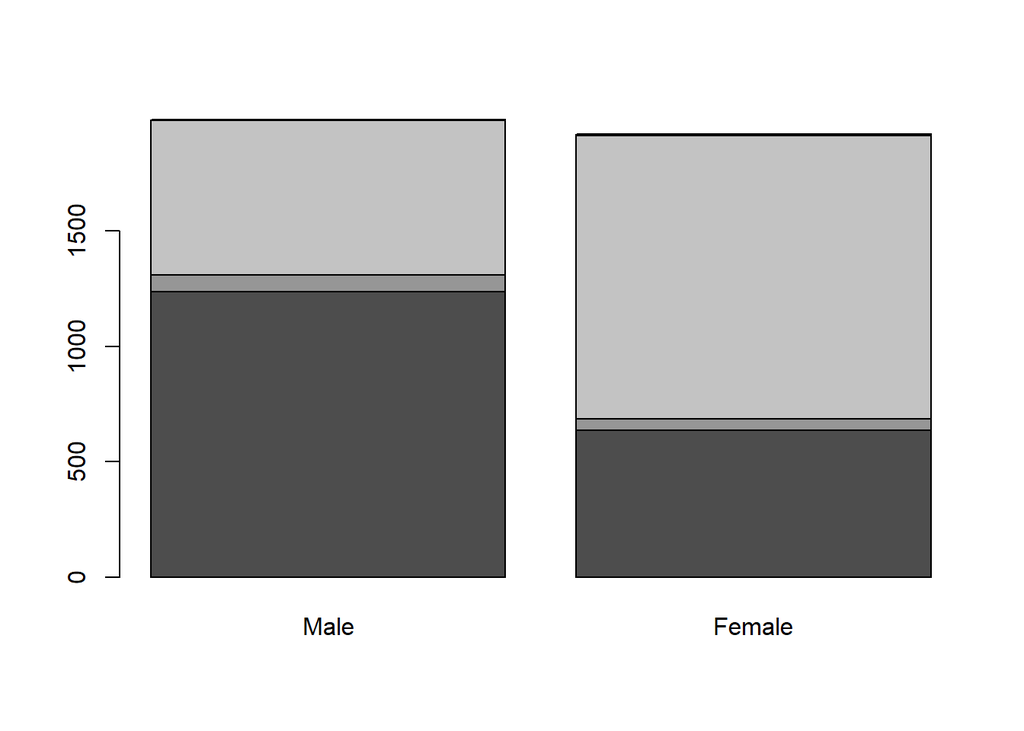

```r
barplot(crosstab) ## stacked by default barplot
```

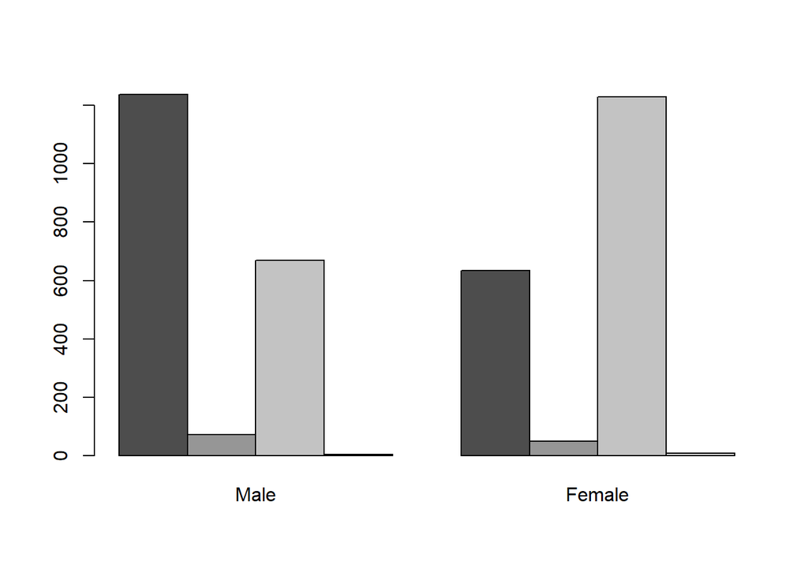

```r
barplot(crosstab, beside = TRUE) ## or unstacked
```

#### Add a legend

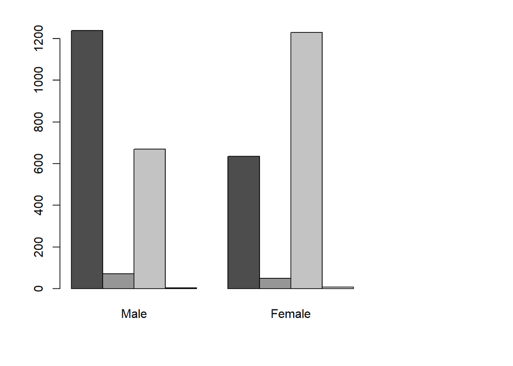

```r
par("mar" = c(5.1,4.1,2.1,10.1), xpd = TRUE) ## add space for legend, and turn off clipping

barplot(crosstab, beside = TRUE)
legend("topright",
       legend = levels(sub_data$EMPSTAT),
       pch = 22,
       pt.bg = grey.colors(4),
       inset = c(-1.2,0),
       title = "Employment Status"
       )
```

#### Add some flair

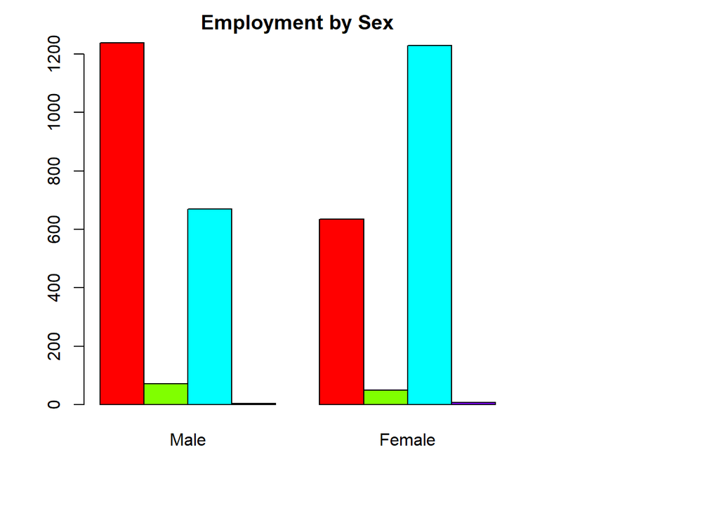

```r
par("mar" = c(5.1,4.1,2.1,10.1), xpd = TRUE) ## add space for legend, and turn off clipping

barplot(crosstab,
        beside = TRUE,
        col = rainbow(4),
        main = "Employment by Sex"
        )

legend("topright",
       legend = levels(sub_data$EMPSTAT),
       pch = 22,
       pt.bg = rainbow(4),
       inset = c(-1.2,0),
       title = "Employment Status"
)
```